# Power_Analysis_In_Class

ZOL 851

November 19, 2015

## Built-in Power Analysis Tools

The built-in power analysis tools in R are found in the “stats” package.

```r
help.search("power", package="stats")
```

We’ll start with the simplist function, `power.t.test`. Examine the argmuents it takes with:

```r
?power.t.test
```

It works by giving it 1 of the first 5 arguments as NULL, and it will calculate the remaining the one NULL value given. For example:

```r
power.t.test(n=6, delta=.2, sd=.1, sig.level=0.05, power=NULL) # Note we want the power
```

```
##
##      Two-sample t test power calculation
##
##               n = 6
##           delta = 0.2
##              sd = 0.1
##       sig.level = 0.05
##           power = 0.8764176
##     alternative = two.sided
##
## NOTE: n is number in *each* group
```

You can change the value you are solving for by adjusting the value set to null.

```r
power.t.test(n=NULL, delta=.2, sd=.1, sig.level=0.05, power=.95)
```

```
##
##      Two-sample t test power calculation
##
##               n = 7.608958
##           delta = 0.2
##              sd = 0.1
##       sig.level = 0.05
##           power = 0.95
##     alternative = two.sided
##
## NOTE: n is number in *each* group
```

```r
# Note this time we want the number of observations
```

n = ~7.6, so we need 8 observations per group to have 95% chance of significance with the same parameters.

In Class Questions: 1. Calculate the power of a two-sample, two-sided t-test when n=12, delta=1.5, sd=2.3. Use a significance level of 0.05.

2. Using the the same t-test, calculate the sample size needed to attain a power of 0.85, with delta=6, sd=4.5. Use a significance level of 0.05.
3. power.anova.test: Calculate the sample size needed for a one-way ANOVA with between-group variance = 3, within-group variance=5, and 4 groups. Use a significance level of 0.05.
4. Calculate the power of a one-way ANOVA with 4 groups, within-group variance = 12, between-group variance=4, 20 subjects in each group. Use a significance level of 0.05.
5. power.prop.test Calculate the power of the test comparing the proportions in two groups (0.5, 0.4), with 20 in each group. Use a significance level of 0.05.

## “pwr” package

Please install the “pwr” packages with: `install.packages("pwr")` Then examine the contents:

```r
library(pwr)
help(package=pwr)
```

More In-Class Questions (using pwr): 7. Calculate the power of the Pearson’s product moment correlation test, where r = 0.8, n = 20, and significance level is 0.05.

8. Calculate the sample size necessary to detect a correlation of r = 0.6, with a power of 0.85 and significance level = 0.05.

## Effect Sizes

In lecture, I said that increasing the effect size (the standardised “difference” between treatment groups) results in an increased power. However, calculation of effect sizes varies from test to test, depending on the underlying distribution of the test statistic. Frequently, we do not know the likely effect size that may occur in an experiment. The best approach is then to do a pilot experiment on a small scale to estimate the likely effect size. In the absence of pilot data, Cohen (1988) provides standard measures of effect size, classified as “small”, “medium”, and “large” for a variety of tests. These effect sizes are built into the pwr package, using the function cohen.ES. Although these “standard” effect sizes are somewhat arbitrary, they can provide a first guide for sample size estimation. Note, however, that a pilot experiment is the recommended way to estimate effect sizes for an experimental study.

More In-Class Exercises:

9. Use cohen.ES to extract “small”, “medium”, and “large” effect sizes for χ-squared, Pearson’s r and proportion tests.
10. Use the above effect sizes to calculate sample sizes with power = 0.8, and sig.level = 0.05, using the following functions from the pwr package: pwr.chisq.test, pwr.r.test, pwr.p.test.
11. Calculate the power of the above tests with sample sizes 10, 50, 100.
12. Calculate the detectable effect size for the above tests when power = 0.8 and n = 10, 50, 100.

## Power calculations from scratch

Let’s pretend we have a null hypothesis distribution with a mean of 0 and sd of 5. Then let’s say we think we have an effect of 3 And we’re always working under alpha = 0.05

```r
mu.null = 0
sd.pop = 5
mu.effect = 3
alpha = 0.05
```

Question 1: if we have a sample size of 25, what is our power?

For this, we first define the effect size & initialize n:

```r
eff.size = (mu.effect-mu.null)/sd.pop
n = 25

# Then we just use the equation
power = pnorm(eff.size*sqrt(n) - qnorm(1-alpha/2))
power
```

```
## [1] 0.8508384
```

Question 2: what if we want a power of 0.8 - what n do we use?

We still have the effect size, and define the wanted power

```r
want.power = 0.8

# Then we just plug and play:
req.n = ((qnorm(want.power) + qnorm(1-alpha/2)) / eff.size)^2
req.n
```

```
## [1] 21.80244
```

```r
# But because we can't have fractions of samples, we round up:
req.n = ceiling(req.n)
req.n
```

```
## [1] 22
```

## Self-made functions

Z test is a statistical test for if a distribution can be approximated by a normal distribution.

Here’s a function to calculate power:

```r
powerZtest = function(alpha = 0.05, sigma, n, delta){
  zcr = qnorm(p = 1-alpha, mean = 0, sd = 1)
  std_err = sigma/sqrt(n)
  power = 1 - pnorm(q = zcr, mean = (delta/std_err), sd = 1)
  return(power)
}
```

Here’s a function to calculate sample size:

```r
sampleSizeZtest = function(alpha = 0.05, sigma, power, delta){
  zcra=qnorm(p = 1-alpha, mean = 0, sd=1)
  zcrb=qnorm(p = power, mean = 0, sd = 1)
  n = ceiling((((zcra+zcrb)*sigma)/delta)^2)
  return(n)
}
```

Let’s test them against the pwr library:

```r
### Data
sigma = 15
h0 = 100
ha = 105

### Power analysis
# Using the self-made function
powerZtest(n = 20, sigma = sigma, delta = (ha-h0))
```

```
## [1] 0.438749
```

```r
# Using the pwr package
pwr.norm.test(d = (ha - h0)/sigma, n = 20, sig.level = 0.05, alternative = "greater")
```

```
##
##      Mean power calculation for normal distribution with known variance
##
##               d = 0.3333333
##               n = 20
##       sig.level = 0.05
##           power = 0.438749
##     alternative = greater
```

```r
### Sample size analysis
# Using the self-made function
sampleSizeZtest(sigma = sigma, power = 0.8, delta = (ha-h0))
```

```
## [1] 56
```

```r
# Using the pwr package
pwr.norm.test(d = (ha - h0)/sigma, power = 0.8, sig.level = 0.05, alternative = "greater")
```

```
##
##      Mean power calculation for normal distribution with known variance
##
##               d = 0.3333333
##               n = 55.64302
##       sig.level = 0.05
##           power = 0.8
##     alternative = greater
```

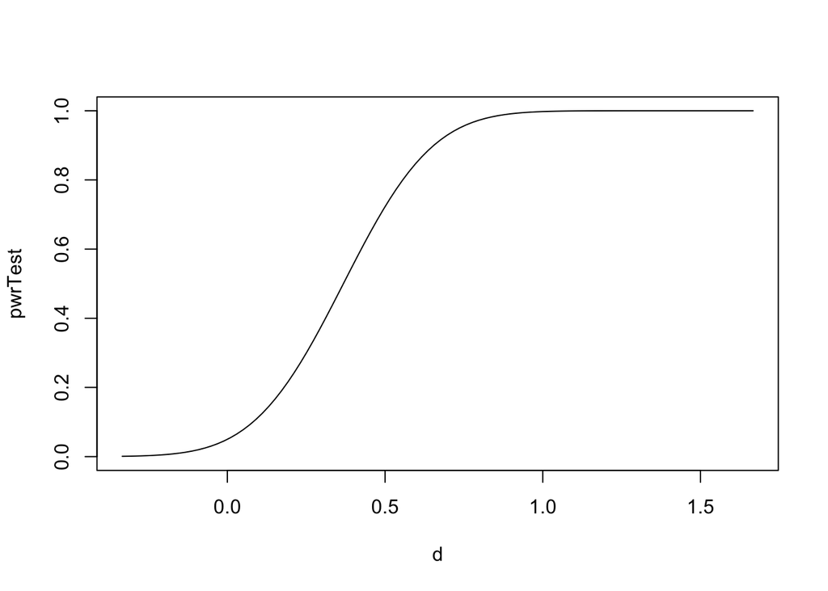

```r
### Power function for the two-sided alternative
ha = seq(95, 125, l = 100)
d = (ha - h0)/sigma
pwrTest = pwr.norm.test(d = d, n = 20, sig.level = 0.05, alternative = "greater")$power
plot(d, pwrTest, type = "l", ylim = c(0, 1))
```

## Power Curves

Calculating specific values of power, sample size or effect size can be illuminating with regard to the statistical restrictions on experimental design and analysis. But frequently a graph tells the story more completely and succinctly. Here we show how to draw power, sample size, and effect size curves using the above functions in R:

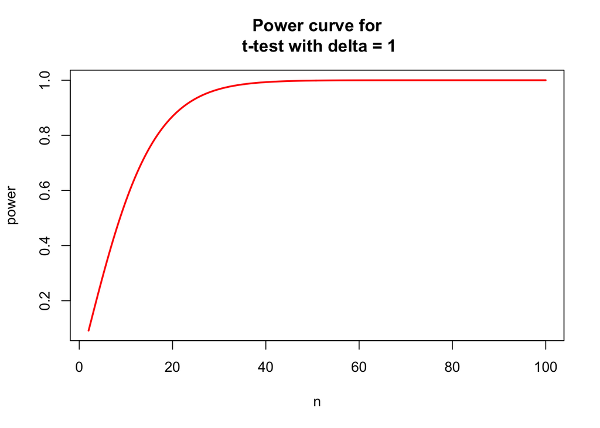

```r
nvals <- seq(2, 100, length.out=200)
powvals <- sapply(nvals, function (x) power.t.test(n=x, delta=1)$power)
plot(nvals, powvals, xlab="n", ylab="power",
main="Power curve for\n t-test with delta = 1",
lwd=2, col="red", type="l")
```

If we are unsure of our effect size, we can also alter delta to see the effect of both effect size and sample size on power:

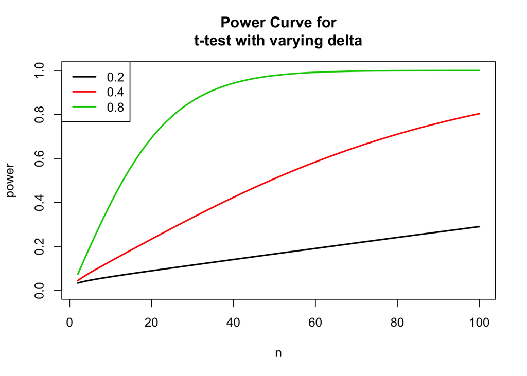

```r
deltas <- c(0.2, 0.4, 0.8)
plot(nvals, seq(0,1, length.out=length(nvals)), xlab="n", ylab="power",
main="Power Curve for\nt-test with varying delta", type="n")
for (i in 1:3) {
  powvals <- sapply(nvals, function (x) power.t.test(n=x, delta=deltas[i])$power)
  lines(nvals, powvals, lwd=2, col=i)
}
legend("topleft", lwd=2, col=1:3, legend=c("0.2", "0.4", "0.8"))
```

More Questions:

13. Make a graph of the relationship between effect size and power, for a sample size of 5, 10, and 20, using power.anova.test. Use 4 groups, with the within-group variance equal to 1, and the between-group variance varying between 0.1 and 1.2.

## Power Analysis by Simulation

Frequently, the complexity of our experimental designs means that we must go far beyond what can be accomplished with standard software, such as the built-in power functions and the pwr package. Fortunately, R can be easily programmed to produce power analyses for any experimental design. The general approach is:

1. Simulate data under the null hypothesis (for checking Type I error probabilities) and also for different effect sizes, to estimate power.
2. Fit the model to the simulated data.
3. Record whether the analysis of the simulated data set was significant, using the usual tests.
4. Store the significance level in a vector.
5. Repeat from step 1. a large number of times.
6. Tabulate how many simulations produced a significant result, and hence calculate power.

Here is an example: Suppose we wish to conduct a study with two fixed factor, leading us to a 2-way analysis of variance (ANOVA), with two levels for each factor. We could simulate data under the null hypothesis (no difference between means) using the following code:

```r
## First set up the design
reps <- 1000
design <- expand.grid(A=c("a", "b"), B=c("c","d"), reps=1:10)
pvals <- vector("numeric", length=reps)
## simulate data under the null hypothesis.
for (i in 1:reps) {
  design$response <- rnorm(40) # random data with zero mean
  ## fit the model
  fit <- aov(response~A*B, data=design)
  ## record the p-value for the interaction term.
  ## You could record other values.
  ## Save the p value
  pvals[i] <- summary(fit)[[1]][["Pr(>F)"]][3]
}
Type1 <- length(which(pvals < 0.05))/reps
print(Type1)
```

```
## [1] 0.053
```

It appears that the Type I error rate is acceptable for the 2-factor ANOVA interaction term. Now to calculate some power statistics. We will calculate power for a difference between means of 2 units, for sample sizes 5, 10, 20.

```r
ssize <- c(5, 10, 20)
reps <- 1000
pvals <- matrix(NA, nrow=reps, ncol=3)
## First set up the design
for (j in 1:3) {
  design <- expand.grid(reps=1:ssize[j], A=c("a", "b"), B=c("c","d"))
  ## simulate data under the null hypothesis.
  for (i in 1:reps) {
    design$response <- c(rnorm(3*ssize[j]), rnorm(ssize[j], mean=2))
    ## fit the model
    fit <- aov(response~A*B, data=design)
    ## record the p-value for the interaction term.
    ## You could record other values.
    ## Save the p value
    pvals[i,j] <- summary(fit)[[1]][["Pr(>F)"]][3]
  }
}
Power <- apply(pvals, 2, function (x) length(which(x < 0.05))/reps)
names(Power) <- as.character(ssize)
print(Power)
```

```
##     5    10    20
## 0.574 0.861 0.991
```

We see that the power is too low for a sample size of 5, but it increases to an acceptable level for 10 replicates per treatment.

Difficult Quesion for fun:

Construct a graph of the relationship between power and sample size for a multiple regression model with 3 predictor variables, over a range of 1 to 10 for each predictor. For the effect size, let the residual error have σ = 5, and β1 = 0.1, β2 = 1 and β3 = 5. Try varying the effect size to examine its effects on power in this case.

## References

Cohen J., 1988. Statistical Power Analysis for the Behavioural Sciences. Routledge, 2nd ed.

Adapted from: http://www.evolutionarystatistics.org/document.pdf